# linear modeling

Jenny Bigman

5/12/2022

Linear models are the bread and butter of data analysis for ecology (and physiology!). They are a statistical model that assess the relationship between the response variable(s) and the explanatory variable(s) (and possibly, their interaction). In univariate statistics, you will have one response variable (y). Like any statistical model, there are assumptions that you have to make sure are not violated. If they are, you cannot trust the results. We will go into this in more detail in a second.

I want to point out that by fitting an ANOVA or ANCOVA, you **are** fitting a linear model! You are just doing it really old fashioned way. The only different between an ANOVA/ANCOVA and a `lm()` is the output (what you see printed). `lm()` is WAY more flexible and is the gold standard. You can add as many variables as you like of any kind, you can center and scale them, you can add correlation structres (e.g., phylogenetic analyses), you can easly plot them in R, you can use an information theoretic approach to compete models (we do this now instead of looking at p-values). If you want to read more on this topic, see the following:

https://www.theanalysisfactor.com/why-anova-and-linear-regression-are-the-same-analysis/

I urge you all to consider never fitting another ANOVA/ANCOVA again! If you start using `lm()` and other linear modeling functions, you will be poised to learn how to ask any question of your data and correctly analyze it.

One thing to note is that people use different terms for the x and y variables. I generally use the term ‘response’ for y and ‘predictor’ for x. Above, you’ll note I used ‘explanatory’ for x. I’ve also seen dependent variable (y) and independent variables (x).

The equation for a linear regression is:

$y = \beta {o} + \beta_{1}x_{1} + \beta_{2}x_{2} + \cdots + \beta_{n}x_{n} + \epsilon$

(the above will render once the script is knitted)

or, y = Bo + B1x1 + B2x2 + B3x3 + e

It is written like this because this is actually how a linear model is mathematically related. Indeed,

- y = response variable
- Bo = intercept
- B = slope of a predictor
- x = data
- e = residual error

This will make more sense when we get into our first model but for now, let’s learn about the assumptions of a linear model.

There are four assumptions that must be met and you will check these assumptions by plotting output of your linear model.

1. linear relationship: y and all x’s are related through a linear relationship
2. independence: residuals are independent
3. homoscedasticity: the residuals have a constant variance at every level of x
4. normality: the residuals of the model are normally distributed

As an example of a linear regression, we are going work with a dataset on Galapagos finches from Sato et al. 2000 Mol. Biol. Evol. http://mbe.oxfordjournals.org/content/18/3/299.full. I have removed some variables we aren’t going to work with and only selected data from one island.

Before we get started, let’s check out our data. We have wing length, beak height, beak length, and sex. We also have 10 different species, and males and females for all species. For this lesson, we won’t worry about the different species, as we will get into that when we look at mixed effects models.

```r
glimpse(morph)
```

```
## Rows: 200
## Columns: 5
## $ taxon  <chr> "Geospiza scandens", "Camarhynchus pauper", "Geospiza fuliginos…
## $ sex    <chr> "M", "M", "M", "M", "M", "M", "M", "M", "F", "M", "M", "M", "F"…
## $ wingl  <dbl> 66, 67, 59, 66, 71, 70, 70, 75, 64, 72, 61, 70, 62, 64, 70, 65,…
## $ beakh  <dbl> 9.2, 8.5, 8.1, 8.4, 13.3, 12.3, 11.1, 15.4, 8.0, 12.6, 8.1, 11.…
## $ ubeakl <dbl> 18.7, 14.0, 13.0, 13.0, 18.0, 15.8, 14.2, 19.4, 11.9, 16.2, 12.…
```

```r
unique(morph$taxon)
```

```
##  [1] "Geospiza scandens"                  "Camarhynchus pauper"
##  [3] "Geospiza fuliginosa"                "Geospiza fortis"
##  [5] "Camarhynchus psittacula"            "Camarhynchus parvulus"
##  [7] "Geospiza fuliginosa parvula"        "Geospiza scandens scandens"
##  [9] "Geospiza prosthemelas prosthemelas" "Geospiza fortis fortis"
```

Let’s work with wing height and berak length and see if there is a relationship between them (question: is beak height correlated with wing length?)

Assumption #1 can be checked using an exploration plot.

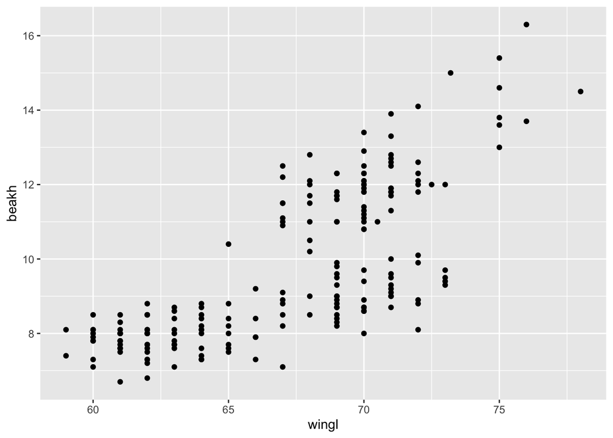

```r
# make a simple plot between wing length and beak height

ggplot(morph) +
    geom_point(aes(x = wingl, y = beakh))
```

It does look like a log transformation would help here. We can compare the residuals with and without one when we run a linear model. For now, let’s log transform.

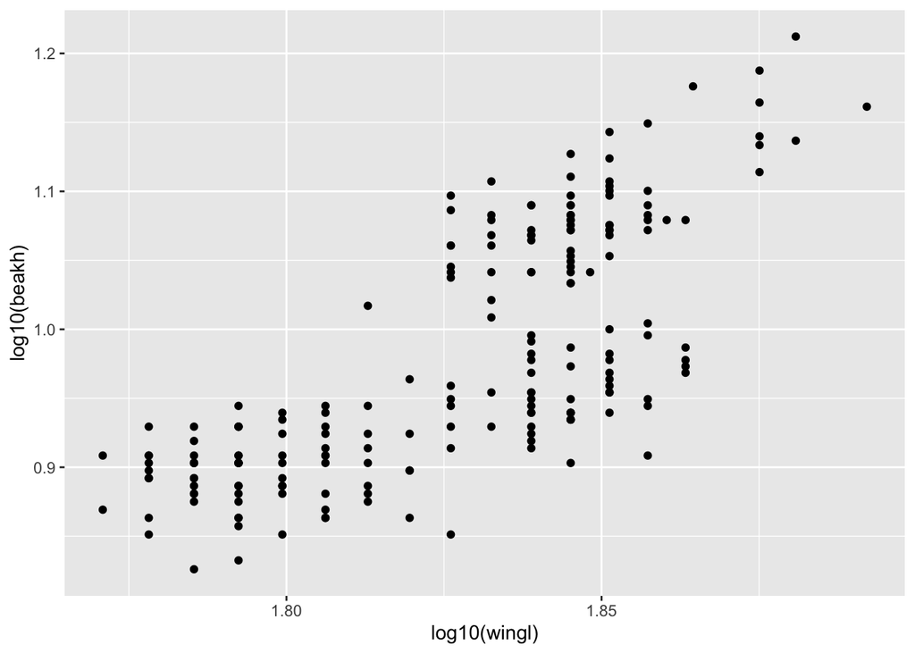

```r
ggplot(morph) +
    geom_point(aes(x = log10(wingl), y = log10(beakh)))
```

Ok, let’s run the linear model. In R, the simplest way to fit a simple linear regression is using lm(y~x). This is fitting the equation above (y = Bo + B1x1…).

```r
fit1 <- lm(beakh ~ wingl, data = morph)

# that's it! now let's look at the summary

summary(fit1)
```

```
##
## Call:
## lm(formula = beakh ~ wingl, data = morph)
##
## Residuals:
##     Min      1Q  Median      3Q     Max
## -3.3436 -1.0933  0.1407  0.9576  3.4226
##
## Coefficients:
##              Estimate Std. Error t value Pr(>|t|)
## (Intercept) -14.36364    1.56022  -9.206   <2e-16 ***
## wingl         0.35843    0.02315  15.483   <2e-16 ***
## ---
## Signif. codes:  0 '***' 0.001 '**' 0.01 '*' 0.05 '.' 0.1 ' ' 1
##
## Residual standard error: 1.392 on 198 degrees of freedom
## Multiple R-squared:  0.5477, Adjusted R-squared:  0.5454
## F-statistic: 239.7 on 1 and 198 DF,  p-value: < 2.2e-16
```

This is a lot of information! Let’s break it down.

‘Call’ tells us what our equation was.

‘Residuals’ tells us the range of our residuals. You roughly want to make sure the min and max and the first and third quartile are equal but opposite. But, we will examine the residuals in more detail later.

‘Coefficients’ are the most important bits. This tells you what the intercept and slope are and if your model is significant.

The ‘(Intercept)’ is the intercept (Bo). This means that when wing length = 0, beak height = -14.4. This seems unrealistic and gets into another (biological) question. We know wing length will never be 0, but at the same time, we want our model to be realistic. One thing you can do is center or standardize your explanatory variables, which will allow you to move the intercept (i.e., move it to 10 cm wing length). Don’t worry about this now, but you should know this is an option and you will see this in many papers. Standardizing is especially useful when you want to compare the relative importance of a predictor(effect size) against others in the model because it puts all variables in the same units.

The ‘wingl’ is the slope of the best fit line between beak height and wing length. It is = 0.36. So for every unit increase in wing length, beak height increases by 0.36 units.

You could look at p-values to see if this relationship is sgnificant, but people don’t really do this anymore. Instead, we look at whether the 95% confidence interval (95%CI) crosses 0. This is of course related to p-values but gets us away from that mindset. This is what a coefficient plot does (I will show you one).

There are a few ways to get the 95% CIs. You could do the math from the summary table (+/- 1.96 * SE). Or you can just use a built-in function.

```r
confint(fit1)
```

```
##                   2.5 %     97.5 %
## (Intercept) -17.4404286 -11.286847
## wingl         0.3127812   0.404087
```

This tells us that the 95% CI of the slope (0.31 - 0.40) does not cross 0 and is significant. We don’t care as much about the intercept, because this just tells us whether it is different from 0 or not (it usually is).

Now, let’s look at some plots to tell us whether our assumptions were met. To do so, use plot(model_object). You will then see options in the console.

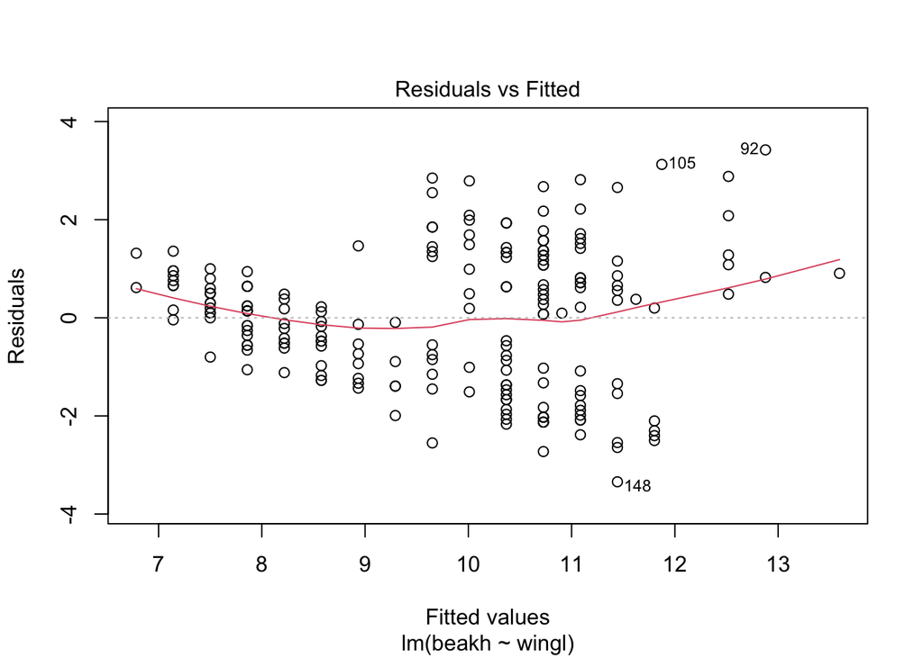

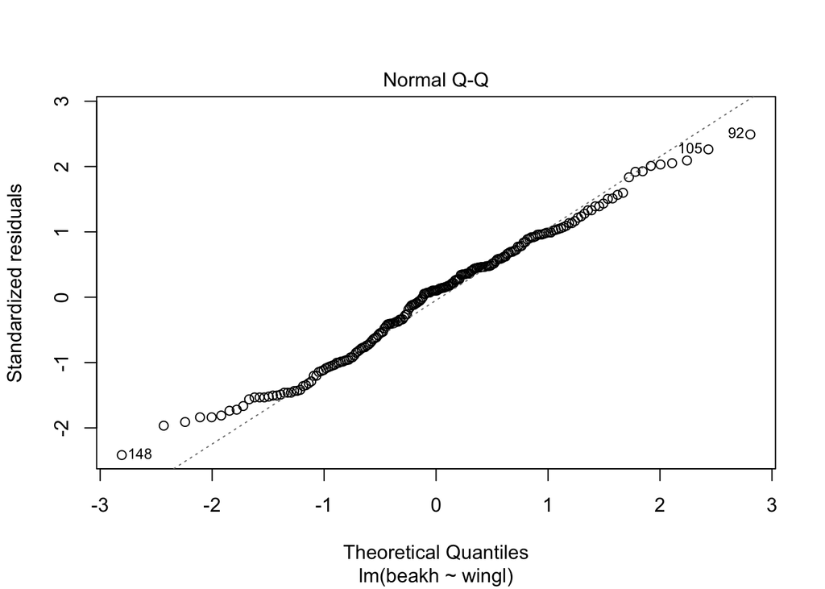

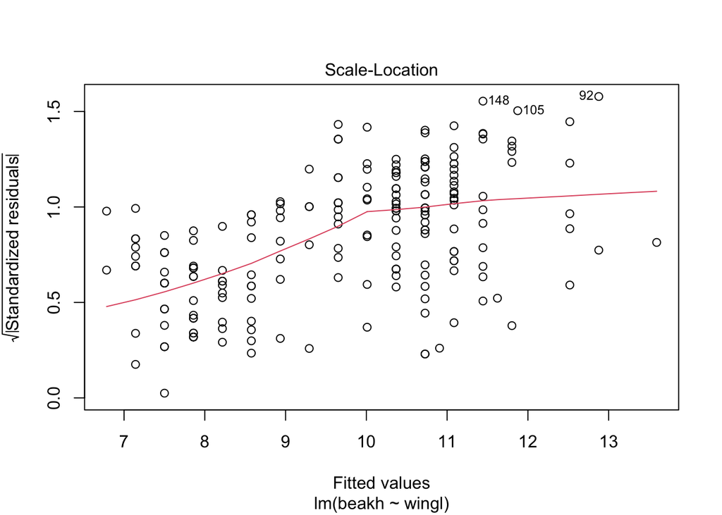

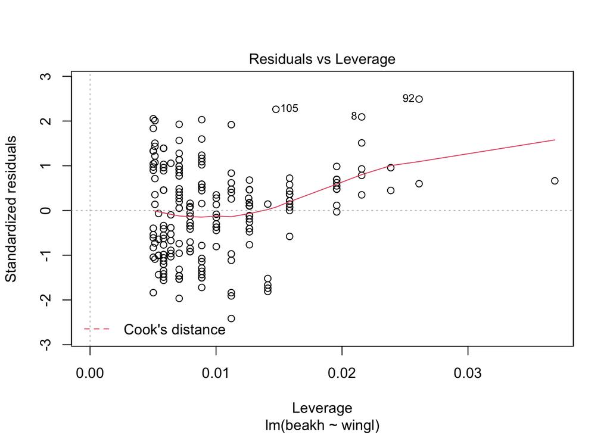

```r
plot(fit1)
```

The first plot is the residuals vs. fitted and is testing for homoscedasticity and independence. Residuals are equal to the difference between each point and it’s predicted value (this will become more clear later). This plot doesn’t look great because it seems like there is more spread in the middle of the plot. You should see no patterning – basically, a scatterplot with no relationship

The second plot is the QQ (Quantile-Quantile) plot – this is testing for normality. For this, you use the ‘fat pen test’. This means that you should be able to cover up the points with a fat pen. This plot looks ok.

The third plot is the scale-location plot and is similar to the first one but here, the residuals are standardized. This amplifies the patterning in the residuals. This plot shows us we may have some issues.

Finally, the fourth plot is showing us whether any data point is exerting leverage on the model fit. You can also test for this by looking at the Cook’s distance value of each point. To do this, you want to use the broom package. This package has LOADS of helpful functions for making model output tidy. Since this is an introduction class, we won’t go into it but here is a quick example.

```r
tidy_output <- broom::augment(fit1)

# examine tidy_output - what does it give you?

cooksd_fit1 <- tidy_output %>%
    select(.cooksd)

which(cooksd_fit1$.cooksd > 0.5) # do any points have a cook's d > 0.5?
```

```
## integer(0)
```

```r
# notice we use a package name then :: this means that we aren't loading the
#entire package but just using a function from it.
```

So, our model is not bad, but let’s see if we can fix some of the patterning in the residuals with a log transformation.

```r
morph <- morph %>%
    mutate(log_wingl = log10(wingl),
                 log_beakh = log10(beakh))

fit2 <- lm(log_beakh ~ log_wingl, data = morph)

summary(fit2)
```

```
##
## Call:
## lm(formula = log_beakh ~ log_wingl, data = morph)
##
## Residuals:
##       Min        1Q    Median        3Q       Max
## -0.143825 -0.049549  0.009808  0.045165  0.119206
##
## Coefficients:
##             Estimate Std. Error t value Pr(>|t|)
## (Intercept)  -3.3808     0.2719  -12.43   <2e-16 ***
## log_wingl     2.3868     0.1488   16.04   <2e-16 ***
## ---
## Signif. codes:  0 '***' 0.001 '**' 0.01 '*' 0.05 '.' 0.1 ' ' 1
##
## Residual standard error: 0.05827 on 198 degrees of freedom
## Multiple R-squared:  0.565,  Adjusted R-squared:  0.5628
## F-statistic: 257.2 on 1 and 198 DF,  p-value: < 2.2e-16
```

Q: What changed? Q: Are beak height and wing length still significantly correlated?

Let’s see if this log transformation fixed the patterning in the residuals.

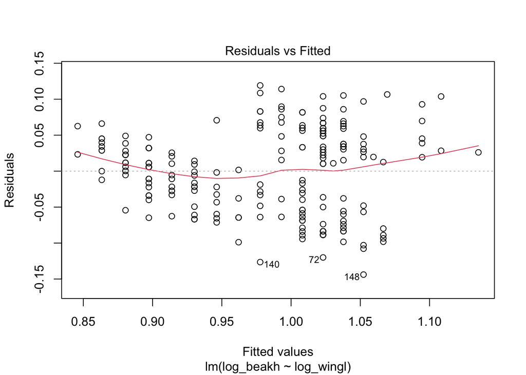

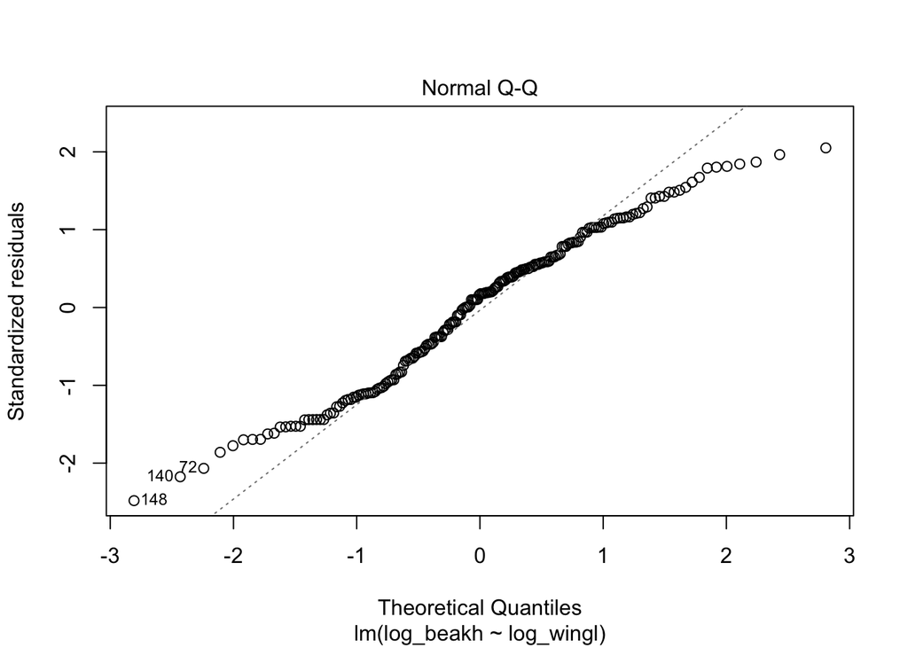

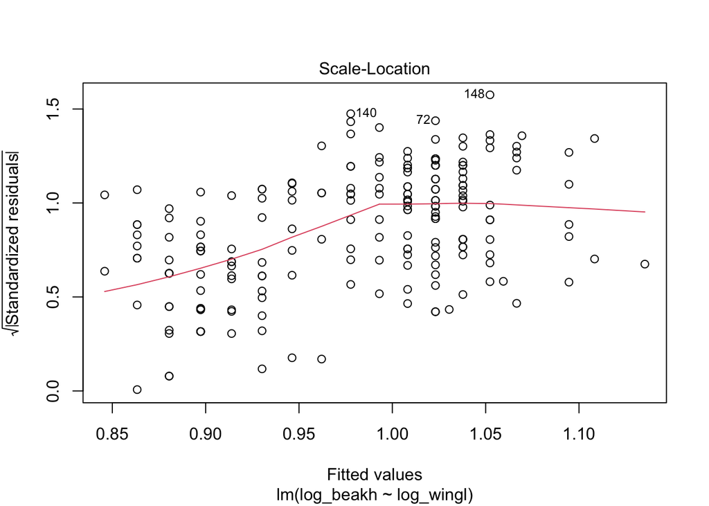

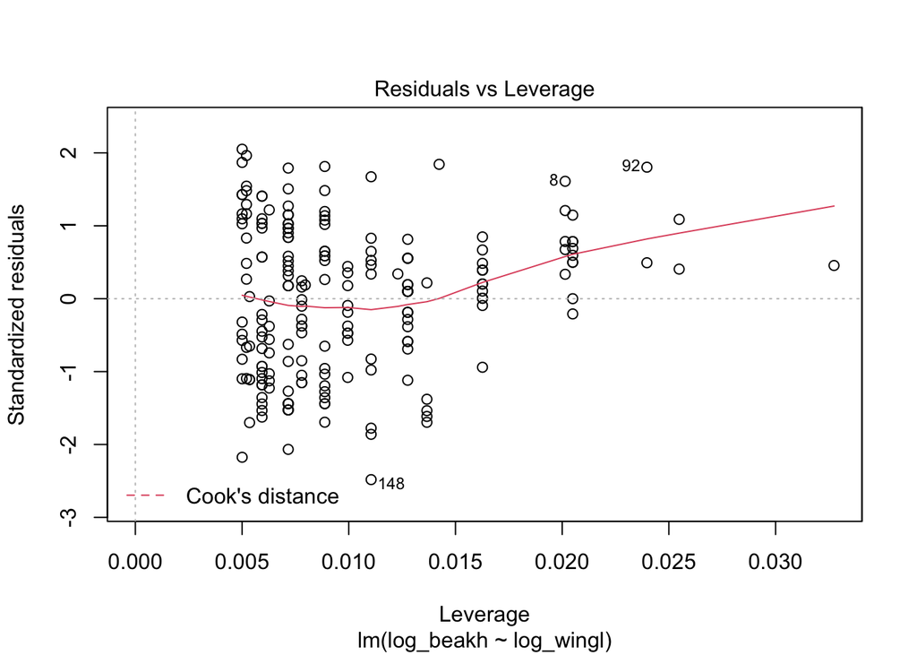

```r
plot(fit2)
```

It does look a little better, but isn’t that noticeable. Maybe something else is going on (hint: we need to use mixed effects models!). For now, let’s plot the fitted line, the 95% CIs and the 95% Prediction Interval.

The 95% CI and 95% PI are different!

The CI definition is that if we repeated the study/model/experiment a very large number of times, then 95% of the computed intervals would contain the true parameter value.

It does NOT mean that there is a 95% probability that the true parameter lies within the interval!

The PI definition is that if we were to measure new, previously unobserved individuals from the same population (not an ecological population but a statistical population), the PI will contain the future observation 95% of the time.

You don’t have to use 95%! This is just common. In Bayesian statistics, we report a few different probabilities so the reader can judge for themselves.

Ok, now let’s plot. There are many ways to obtain the data behind a fitted line, confidence interval, and prediction interval. I always do it by hand – this way you learn what is happening!

One thing to note about R is that there are usually many ways of doing things in different packages or using different functions (and sometimes, the same function but in a different modeling framework will be called something else. This is because packages are developed by different people, so they aren’t always consistent.

Let’s start with the fit line. We want to obtain the fitted value of y for each value of x. It is somewhat confusing that the function is called ‘predict’ and not ‘fitted’ (this is because sometimes, the fitted value is called predicted value, but this is different than the prediction interval).

Let’s compute the fitted valeus (the expected value of y at each value of x) as well as the error associated with the fitted valeus (the 95% CIs). I’m going to go ahead and wrap this in `as_tibble()` so it returns a dataframe (it would return a matrix/array if not).

```r
fitted_vals <- as_tibble(predict(fit2, interval = "confidence"))

# add this back into our dataframe and rename columns
#as to not get confused later when we add in the predicted values

morph <- bind_cols(morph, fitted_vals) %>%
    rename(fitted_val = fit,
                 fit_lwr = lwr,
                 fit_upr = upr)
```

So, we just joined two dataframes! There are many ways to join dataframes together. Enter ‘? merge’ in the console. This is one of my favorties, although dplyr improved on this with the [join family](https://dplyr.tidyverse.org/reference/mutate-joins.html). For our purposes, we can use ‘bind_cols’ because we are joining dataframes that don’t share any data.

Now, let’s compute the predictions. For this, we need to feed ‘new data’ into the predict function. To do so, we can create a new ‘dataframe’ of new x values to predict from. These are different than your data. Right now, we are only fitting a model with one predictor but if you have more than one, this dataframe would have more columns.

```r
length_dat <- length(morph$log_wingl)
min_dat <- min(morph$log_wingl)
max_dat <- max(morph$log_wingl)

newdat_preds <- expand.grid(
  log_wingl = seq(from = min_dat,
                        to = max_dat,
                        length.out = length_dat))

pred_dat_lm <- as_tibble(
    predict(fit2, newdata = newdat_preds, interval = "prediction"))

pred_dat_lm$p_log_wingl <- newdat_preds$log_wingl

# we aren't going to add this dataframe in so I can show you how to build a ggplot with more than one dataframe
```

We now want to create some plots. Our fitted values, and the upper and lower confidence and intervals are already in our dataset. Our prediction intervals are in the ‘pred_dat_lm’ dataframe. We will use ggplot() with geom_point() for the data, geom_line() for the fit line, and geom_ribbon for the confidence and prediction intervals. Plots with ggplot(), especially once you format them for publication, can get really long (lots of lines!). This is because ggplot() builds plots iteratively. This means we have to pay attention to the order in which we add parts to the plot. Let’s see how this works and how the plot will change if we don’t think about order.

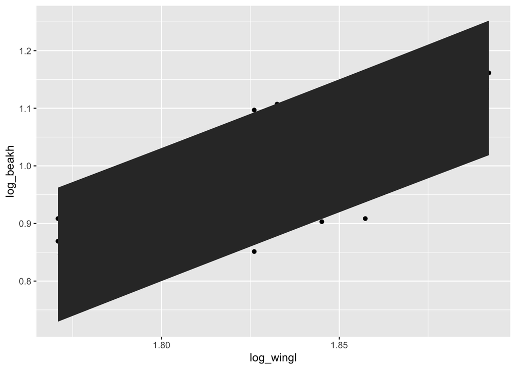

```r
ggplot(morph) +
    geom_point(aes(x = log_wingl, y = log_beakh)) +
    geom_line(aes(x = log_wingl, y = fitted_val)) +
    geom_ribbon(aes(ymin = fit_lwr, ymax = fit_upr, x = log_wingl)) +
    geom_ribbon(data = pred_dat_lm, aes(ymin = lwr, ymax = upr, x = p_log_wingl))
```

This plot looks horrible! We can’t see anything. We will want to specify lighter colors, play with transparency, and probably start with the intervals and then add the lines and points on top. We will want to start with the prediction interval first since it is the widest. I will build it iteratively below so you can play around with transparency and colors.

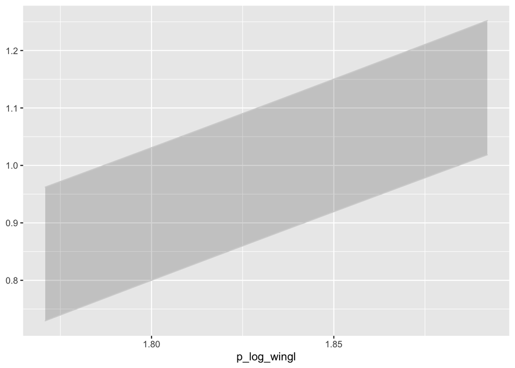

```r
ggplot() +
        geom_ribbon(data = pred_dat_lm, aes(ymin = lwr, ymax = upr, x = p_log_wingl),
                                color = "lightgrey", alpha = 0.2) # alpha is transparency
```

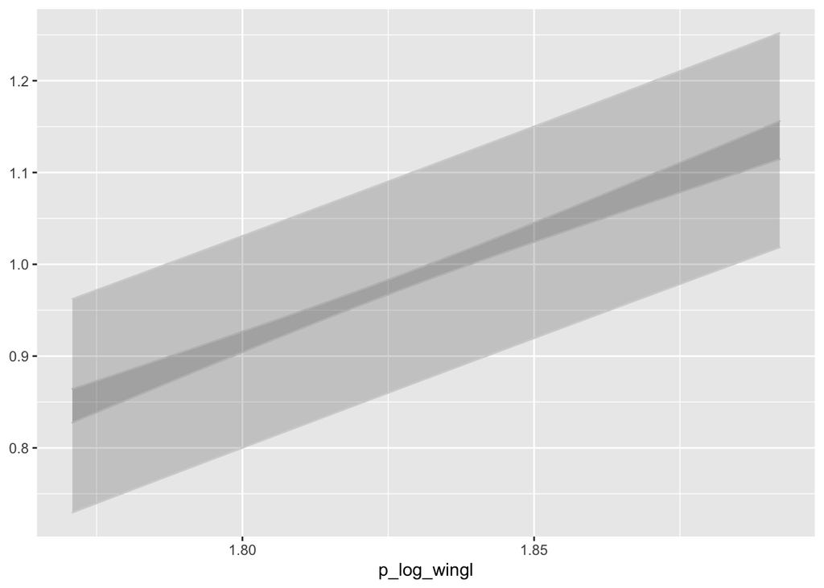

```r
ggplot() +
        geom_ribbon(data = pred_dat_lm, aes(ymin = lwr, ymax = upr, x = p_log_wingl),
                                color = "lightgrey", alpha = 0.2) +
        geom_ribbon(data = morph, aes(ymin = fit_lwr, ymax = fit_upr, x = log_wingl),
                                                                color = "grey", alpha = 0.2)
```

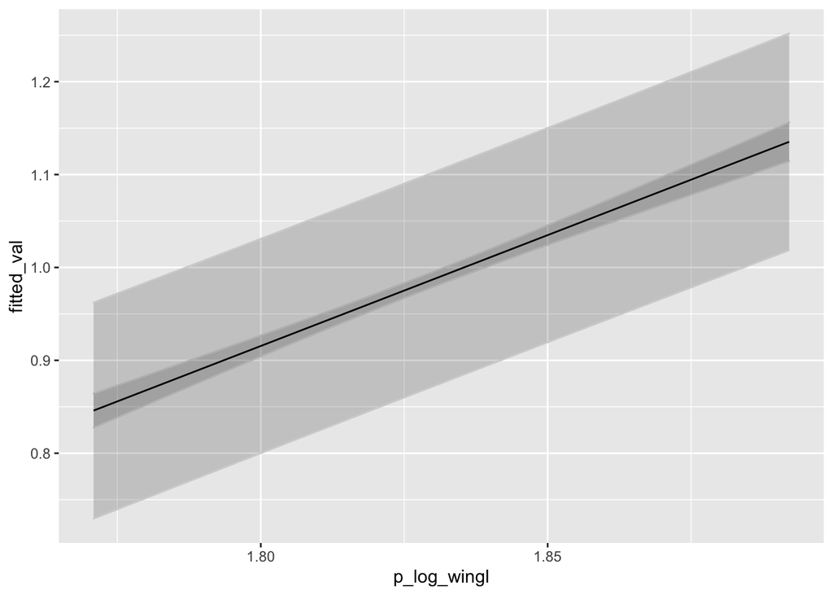

```r
ggplot() +
        geom_ribbon(data = pred_dat_lm, aes(ymin = lwr, ymax = upr, x = p_log_wingl),
                                color = "lightgrey", alpha = 0.2) +
        geom_ribbon(data = morph, aes(ymin = fit_lwr, ymax = fit_upr, x = log_wingl),
                                                                color = "grey", alpha = 0.2) +
        geom_line(data = morph, aes(x = log_wingl, y = fitted_val), size = 0.5)
```

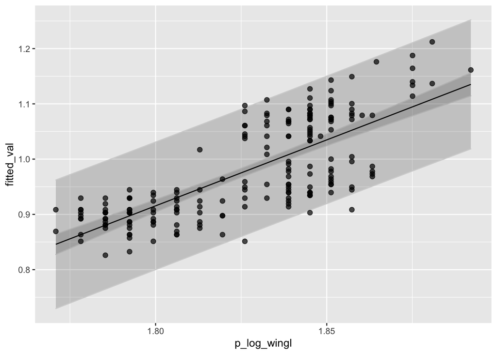

```r
ggplot() +
        geom_ribbon(data = pred_dat_lm, aes(ymin = lwr, ymax = upr, x = p_log_wingl),
                                color = "lightgrey", alpha = 0.2) +
        geom_ribbon(data = morph, aes(ymin = fit_lwr, ymax = fit_upr, x = log_wingl),
                                                                color = "grey", alpha = 0.2) +
        geom_line(data = morph, aes(x = log_wingl, y = fitted_val), size = 0.5) +
        geom_point(data = morph, aes(x = log_wingl, y = log_beakh), alpha = 0.7, size = 2)
```

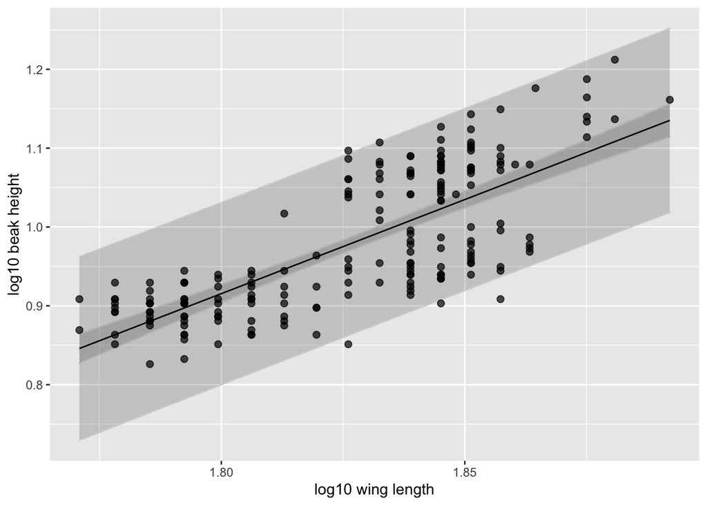

```r
# let's change the x and y axis titles

ggplot() +
        geom_ribbon(data = pred_dat_lm, aes(ymin = lwr, ymax = upr, x = p_log_wingl),
                                color = "lightgrey", alpha = 0.2) +
        geom_ribbon(data = morph, aes(ymin = fit_lwr, ymax = fit_upr, x = log_wingl),
                                                                color = "grey", alpha = 0.2) +
        geom_line(data = morph, aes(x = log_wingl, y = fitted_val), size = 0.5) +
        geom_point(data = morph, aes(x = log_wingl, y = log_beakh), alpha = 0.7, size = 2) +
        xlab("log10 wing length") +
        ylab("log10 beak height")
```

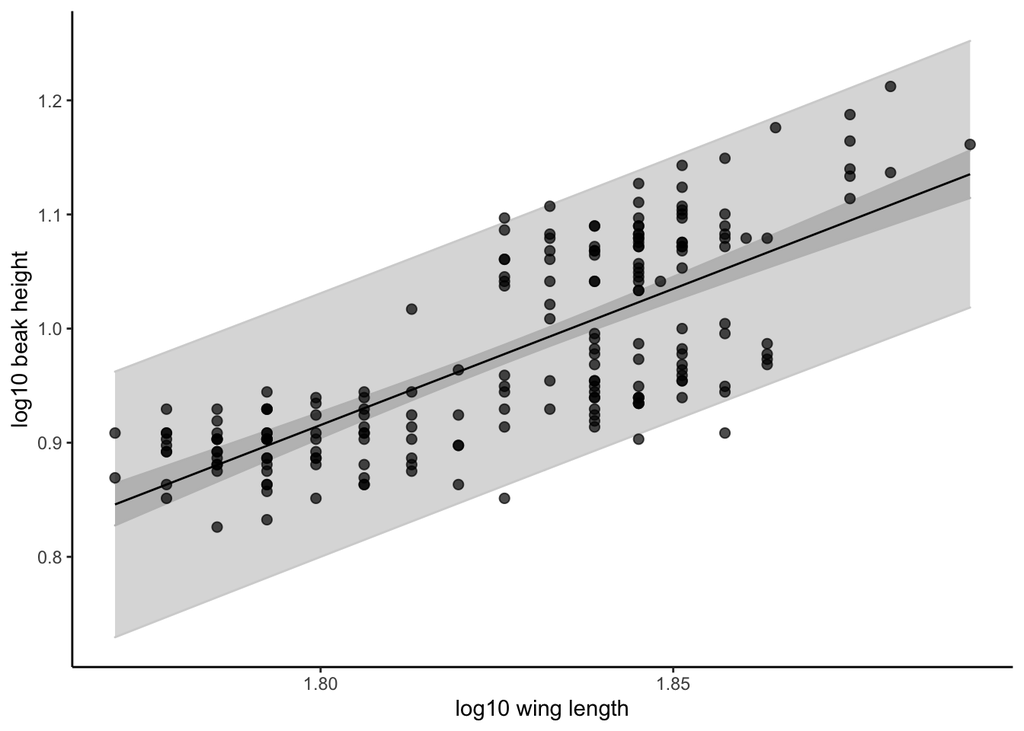

```r
# let's add a theme

ggplot() +
        geom_ribbon(data = pred_dat_lm, aes(ymin = lwr, ymax = upr, x = p_log_wingl),
                                color = "lightgrey", alpha = 0.2) +
        geom_ribbon(data = morph, aes(ymin = fit_lwr, ymax = fit_upr, x = log_wingl),
                                                                color = "grey", alpha = 0.2) +
        geom_line(data = morph, aes(x = log_wingl, y = fitted_val), size = 0.5) +
        geom_point(data = morph, aes(x = log_wingl, y = log_beakh), alpha = 0.7, size = 2) +
        xlab("log10 wing length") +
        ylab("log10 beak height") +
        theme_classic()
```

Ok, that plot is starting to look good. We will learn more about customizations later in the last section.

Let’s move on to adding more variables in our linear model. What about sex? The question here could be two-fold. One, do females have a greater beak height for a given size than males? Second, does the relationship between beak height and wing length differ between males and females?

Q: Does anyone know the difference between these two questions? How would we code these models?

Let’s tackle the first question.

```r
fit3 <- lm(log_beakh ~ log_wingl + sex, data = morph)

summary(fit3)
```

```
##
## Call:
## lm(formula = log_beakh ~ log_wingl + sex, data = morph)
##
## Residuals:
##       Min        1Q    Median        3Q       Max
## -0.140853 -0.046597  0.006402  0.041516  0.119580
##
## Coefficients:
##              Estimate Std. Error t value Pr(>|t|)
## (Intercept) -3.549341   0.282746 -12.553   <2e-16 ***
## log_wingl    2.485879   0.155801  15.955   <2e-16 ***
## sexM        -0.018425   0.009209  -2.001   0.0468 *
## ---
## Signif. codes:  0 '***' 0.001 '**' 0.01 '*' 0.05 '.' 0.1 ' ' 1
##
## Residual standard error: 0.05784 on 197 degrees of freedom
## Multiple R-squared:  0.5737, Adjusted R-squared:  0.5693
## F-statistic: 132.5 on 2 and 197 DF,  p-value: < 2.2e-16
```

Challenge: who wants to try walk me through this output? How similar is it to fit2?

So what is confusing about the lm output in R is how this output is written. We see ‘(Intercept)’, ‘log_wingl’, and ‘sexM’. What this actually means is: intercept-female, slope, difference between intercept-male and intercept female. In words, on the log10 scale, females have a beak height of -3.55 at 0 wing length, males have a beak height of (-3.55 + - 0.02) at 0 wing length, and for every unit increase in wing length, beak height inreases by 2.49 units.

Let’s use some dplyr magic to get this output into a more readable form.

```r
intercept_female <- coef(fit3)[1] # what does this do?
intercept_male_diff <- coef(fit3)[3]
intercept_male <- intercept_female + intercept_male_diff
slope <- coef(fit3)[2]

fit3_coefs <- cbind(intercept_female, intercept_male, slope)
```

Let’s add ine 95% confidence intervals in case you wanted to make a table for a paper

```r
intercept_female_lwr <- confint(fit3)[1, 1] # why do I need to specify two numbers here?
intercept_female_upr <- confint(fit3)[1, 2] # why do I need to specify two numbers here?


intercept_male_diff_lwr <- confint(fit3)[3, 1]
intercept_male_diff_upr <- confint(fit3)[3, 2]


intercept_male_lwr <- intercept_female_lwr + intercept_male_diff_lwr
intercept_male_upr <- intercept_female_upr + intercept_male_diff_upr


slope_lwr <- confint(fit3)[2, 1]
slope_upr <- confint(fit3)[2, 2]
```

Now, let’s plot. We have two separate fit lines for males and females, so we will extract fitted values, and the confidence and prediction intervals separately.

```r
# first, separate the males and females into separate datasets

morph_females <- morph %>%
    filter(sex == "F")

morph_males <- morph %>%
    filter(sex == "M")

# second, create new dat (x values) for each for both fitted and predicted values

# fitted
females_newdat_fits <- expand.grid(
    log_wingl = morph_males$log_wingl,
    sex = "F")

males_newdat_fits <- expand.grid(
    log_wingl = morph_males$log_wingl,
    sex = "M")


fits_females <- predict(fit3, newdata = females_newdat_fits,
                            interval = "confidence") %>%
    bind_cols(females_newdat_fits)

fits_males <- predict(fit3, newdata = males_newdat_fits,
                            interval = "confidence") %>%
    bind_cols(males_newdat_fits)


# predicted

# females
len_females <- length(morph_females$log_wingl)
min_females <- min(morph_females$log_wingl)
max_females <- max(morph_females$log_wingl)

females_newdat_preds <- expand.grid(
    log_wingl = seq(from = min_females, to = max_females, length.out = len_females),
    sex = "F")

preds_females <- predict(fit3, newdata = females_newdat_preds,
                            interval = "confidence") %>%
    bind_cols(females_newdat_preds)


# males
len_males <- length(morph_males$log_wingl)
min_males <- min(morph_males$log_wingl)
max_males <- max(morph_males$log_wingl)

males_newdat_preds <- expand.grid(
    log_wingl = seq(from = min_males, to = max_males, length.out = len_males),
    sex = "M")

preds_males <- predict(fit3, newdata = males_newdat_preds,
                            interval = "confidence") %>%
    bind_cols(males_newdat_preds)
```

Whew, that was a lot! Now, let’s build the plot, making females and males different colors. And, let’s just plot the confidence intervals so it is not too busy.

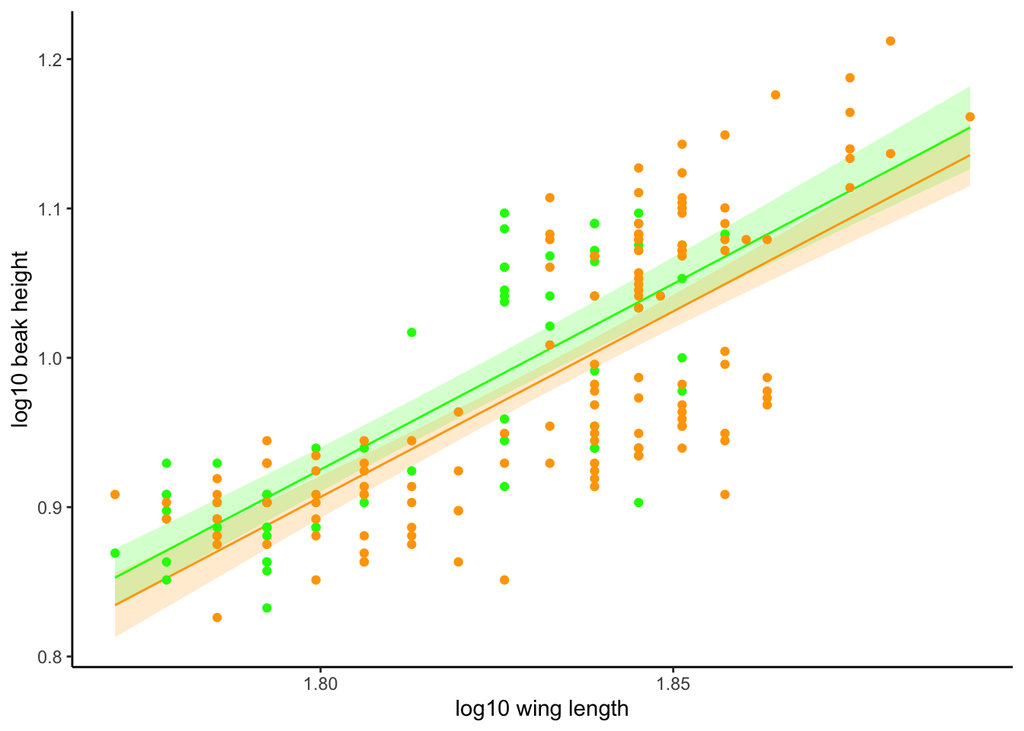

```r
ggplot() +
        geom_ribbon(data = fits_females, aes(ymin = lwr, ymax = upr, x = log_wingl),
                                fill = "green", alpha = 0.2) +
        geom_ribbon(data = fits_males, aes(ymin = lwr, ymax = upr, x = log_wingl),
                                fill = "orange", alpha = 0.2) +
        geom_line(data = fits_females, aes(x = log_wingl, y = fit), color = "green") +
        geom_line(data = fits_males, aes(x = log_wingl, y = fit), color = "orange") +
        geom_point(data = morph_females, aes( x = log_wingl, y = log_beakh), color = "green") +
        geom_point(data = morph_males, aes( x = log_wingl, y = log_beakh), color = "orange") +
        xlab("log10 wing length") +
        ylab("log10 beak height") +
        theme_classic()
```

But, what if we didn’t catch this because they have different slopes (i.e., different relationships between beak height and wing length?). We have to run a different model to ask this question. We have to add an interaction between sex and wing length, which allows the slope between beak height and wing length to differ (and we can see if this difference is significant).

```r
# we can add an interaction by adding the variables together by a :
fit4 <- lm(log_beakh ~ log_wingl + sex + log_wingl:sex, data = morph)

summary(fit4)
```

```
##
## Call:
## lm(formula = log_beakh ~ log_wingl + sex + log_wingl:sex, data = morph)
##
## Residuals:
##       Min        1Q    Median        3Q       Max
## -0.142332 -0.046823  0.008238  0.043930  0.119609
##
## Coefficients:
##                Estimate Std. Error t value Pr(>|t|)
## (Intercept)     -3.3061     0.5071  -6.520 5.84e-10 ***
## log_wingl        2.3518     0.2795   8.415 8.16e-15 ***
## sexM            -0.3731     0.6133  -0.608    0.544
## log_wingl:sexM   0.1948     0.3369   0.578    0.564
## ---
## Signif. codes:  0 '***' 0.001 '**' 0.01 '*' 0.05 '.' 0.1 ' ' 1
##
## Residual standard error: 0.05793 on 196 degrees of freedom
## Multiple R-squared:  0.5744, Adjusted R-squared:  0.5679
## F-statistic: 88.17 on 3 and 196 DF,  p-value: < 2.2e-16
```

```r
# we can also use a shorthand:
fit5 <- lm(log_beakh ~ log_wingl * sex,  data = morph)

summary(fit5)
```

```
##
## Call:
## lm(formula = log_beakh ~ log_wingl * sex, data = morph)
##
## Residuals:
##       Min        1Q    Median        3Q       Max
## -0.142332 -0.046823  0.008238  0.043930  0.119609
##
## Coefficients:
##                Estimate Std. Error t value Pr(>|t|)
## (Intercept)     -3.3061     0.5071  -6.520 5.84e-10 ***
## log_wingl        2.3518     0.2795   8.415 8.16e-15 ***
## sexM            -0.3731     0.6133  -0.608    0.544
## log_wingl:sexM   0.1948     0.3369   0.578    0.564
## ---
## Signif. codes:  0 '***' 0.001 '**' 0.01 '*' 0.05 '.' 0.1 ' ' 1
##
## Residual standard error: 0.05793 on 196 degrees of freedom
## Multiple R-squared:  0.5744, Adjusted R-squared:  0.5679
## F-statistic: 88.17 on 3 and 196 DF,  p-value: < 2.2e-16
```

Ok, let’s dig into the summary of this.

```r
summary(fit4)
```

```
##
## Call:
## lm(formula = log_beakh ~ log_wingl + sex + log_wingl:sex, data = morph)
##
## Residuals:
##       Min        1Q    Median        3Q       Max
## -0.142332 -0.046823  0.008238  0.043930  0.119609
##
## Coefficients:
##                Estimate Std. Error t value Pr(>|t|)
## (Intercept)     -3.3061     0.5071  -6.520 5.84e-10 ***
## log_wingl        2.3518     0.2795   8.415 8.16e-15 ***
## sexM            -0.3731     0.6133  -0.608    0.544
## log_wingl:sexM   0.1948     0.3369   0.578    0.564
## ---
## Signif. codes:  0 '***' 0.001 '**' 0.01 '*' 0.05 '.' 0.1 ' ' 1
##
## Residual standard error: 0.05793 on 196 degrees of freedom
## Multiple R-squared:  0.5744, Adjusted R-squared:  0.5679
## F-statistic: 88.17 on 3 and 196 DF,  p-value: < 2.2e-16
```

Q: Does anyone want to take a stab at what this means? Hint: it is similar to the last one in terms of the names of the coefficients.

Q: Do males and females have significantly different beak heights and a given wing length? (i.e., different intercepts)

Q: Do males and females have a significantly different relationship between beak height and wing length?

Let’s plot! The code will look very similar to the previous code for the model with no interaction. Reminder: we already have our morph datasets separated by males and females.

```r
# fitted
females_newdat_fits <- expand.grid(
    log_wingl = morph_males$log_wingl,
    sex = "F")

males_newdat_fits <- expand.grid(
    log_wingl = morph_males$log_wingl,
    sex = "M")


fits_females_int <- predict(fit4, newdata = females_newdat_fits,
                            interval = "confidence") %>%
    bind_cols(females_newdat_fits)

fits_males_int <- predict(fit4, newdata = males_newdat_fits,
                            interval = "confidence") %>%
    bind_cols(males_newdat_fits)


# predicted

# females
len_females <- length(morph_females$log_wingl)
min_females <- min(morph_females$log_wingl)
max_females <- max(morph_females$log_wingl)

females_newdat_preds <- expand.grid(
    log_wingl = seq(from = min_females, to = max_females, length.out = len_females),
    sex = "F")

preds_females_int <- predict(fit4, newdata = females_newdat_preds,
                            interval = "confidence") %>%
    bind_cols(females_newdat_preds)


# males
len_males <- length(morph_males$log_wingl)
min_males <- min(morph_males$log_wingl)
max_males <- max(morph_males$log_wingl)

males_newdat_preds <- expand.grid(
    log_wingl = seq(from = min_males, to = max_males, length.out = len_males),
    sex = "M")

preds_males_int <- predict(fit4, newdata = males_newdat_preds,
                            interval = "confidence") %>%
    bind_cols(males_newdat_preds)
```

Let’s plot.

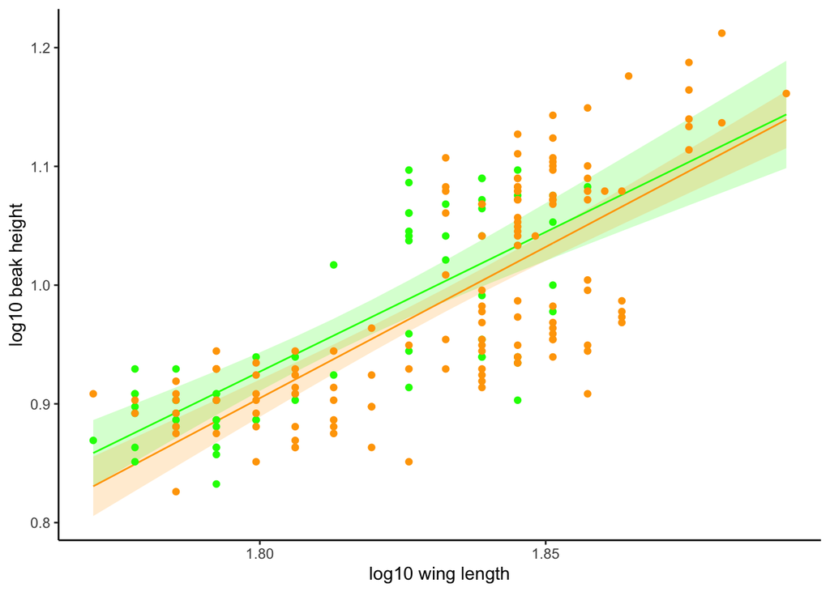

```r
ggplot() +
        geom_ribbon(data = fits_females_int, aes(ymin = lwr, ymax = upr, x = log_wingl),
                                fill = "green", alpha = 0.2) +
        geom_ribbon(data = fits_males_int, aes(ymin = lwr, ymax = upr, x = log_wingl),
                                fill = "orange", alpha = 0.2) +
        geom_line(data = fits_females_int, aes(x = log_wingl, y = fit), color = "green") +
        geom_line(data = fits_males_int, aes(x = log_wingl, y = fit), color = "orange") +
        geom_point(data = morph_females, aes( x = log_wingl, y = log_beakh), color = "green") +
        geom_point(data = morph_males, aes( x = log_wingl, y = log_beakh), color = "orange") +
        xlab("log10 wing length") +
        ylab("log10 beak height") +
        theme_classic()
```

Q: Does this look different?

Ok, one more thing I want to show you before we move on to mixed effects models. What if we had two continuous variables? How would we obtain fitted and predicted values and plot?

Let’s pretend that we had mass data already in the dataset. I am going to simulate it and add it to our morph dataset.

```r
mass <- rnorm(n = 200, mean = 100, sd = 3)

morph$mass <- mass # another way to add a column
```

Let’s fit a model with beak height varying with wing length and mass.

```r
morph <- morph %>%
    mutate(log_mass = log10(mass))

fit6 <- lm(log_beakh ~ log_wingl * log_mass, data = morph)

summary(fit6)
```

```
##
## Call:
## lm(formula = log_beakh ~ log_wingl * log_mass, data = morph)
##
## Residuals:
##      Min       1Q   Median       3Q      Max
## -0.14521 -0.05058  0.01036  0.04350  0.11893
##
## Coefficients:
##                    Estimate Std. Error t value Pr(>|t|)
## (Intercept)         -40.222     39.954  -1.007    0.315
## log_wingl            22.319     21.915   1.018    0.310
## log_mass             18.419     19.970   0.922    0.357
## log_wingl:log_mass   -9.965     10.953  -0.910    0.364
##
## Residual standard error: 0.05836 on 196 degrees of freedom
## Multiple R-squared:  0.5681, Adjusted R-squared:  0.5615
## F-statistic: 85.94 on 3 and 196 DF,  p-value: < 2.2e-16
```

Q: What does this output mean?

Let’s obtain the fitted values and the confidence and prediction intervals. We have to decide what factor we are plotting on the x-axis. Let’s first plot mass on the x-axis and then plot wing length on the x-axis. When you are obtaining fitted and predicted values, you hold the other predictor(s) (x variables) at their mean.

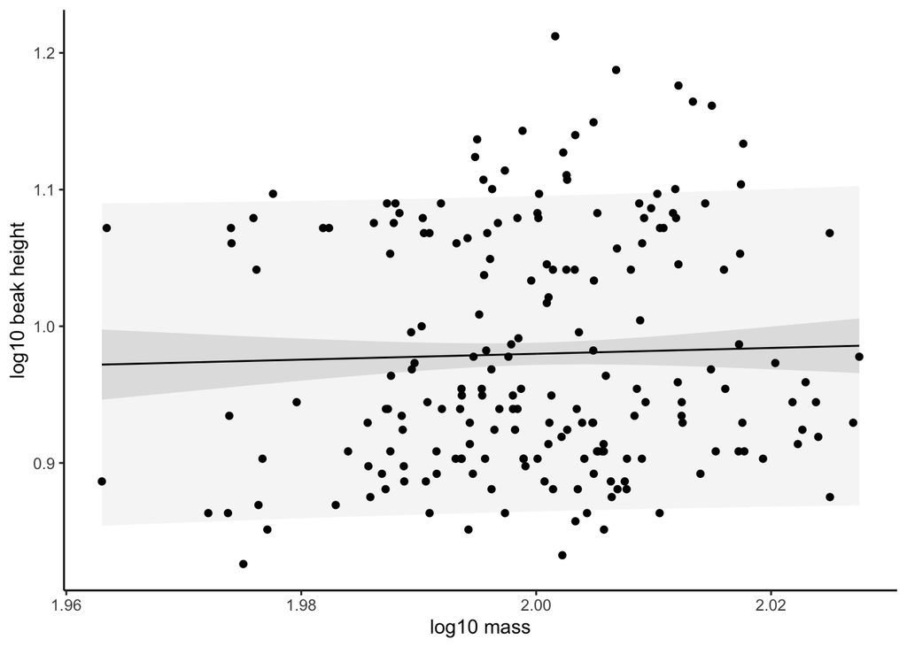

```r
new_dat_mass_fits <- expand_grid(
    log_wingl = mean(morph$log_wingl),
    log_mass = morph$log_mass
)

fit6_mass_fits <- as_tibble(
    predict(fit6, newdata = new_dat_mass_fits, interval = "confidence")) %>%
    bind_cols(new_dat_mass_fits)

new_dat_mass_preds <- expand_grid(
    log_wingl = mean(morph$log_wingl),
    log_mass = seq(from = min(morph$log_mass),
                                 to = max(morph$log_mass),
                                 length.out = nrow(morph)))

fit6_mass_preds <- as_tibble(
    predict(fit6, newdata = new_dat_mass_preds, interval = "prediction"))  %>%
    bind_cols(new_dat_mass_preds)

# plot

ggplot() +
        geom_ribbon(data = fit6_mass_preds, aes(ymin = lwr, ymax = upr, x = log_mass),
                                fill = "lightgrey", alpha = 0.2) +
        geom_ribbon(data = fit6_mass_fits, aes(ymin = lwr, ymax = upr, x = log_mass),
                                fill = "lightgrey", alpha = 0.6) +
        geom_line(data = fit6_mass_fits, aes(x = log_mass, y = fit), color = "black") +
        geom_point(data = morph, aes( x = log_mass, y = log_beakh), color = "black") +
        xlab("log10 mass") +
        ylab("log10 beak height") +
        theme_classic()
```

Clearly, beak height is not well predicted my mass. That’s ok! Now, let’s plot wing height on the x-axis.

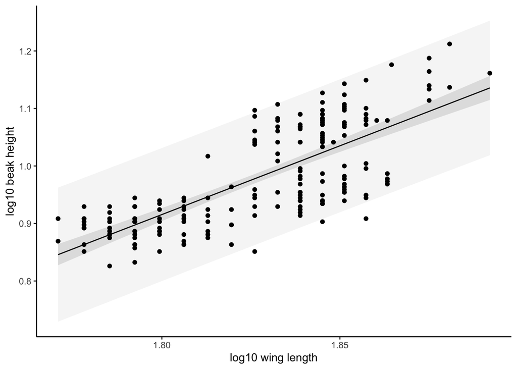

```r
new_dat_wingl_fits <- expand_grid(
    log_wingl = morph$log_wingl,
    log_mass = mean(morph$log_mass)
)

fit6_wingl_fits <- as_tibble(
    predict(fit6, newdata = new_dat_wingl_fits, interval = "confidence")) %>%
    bind_cols(new_dat_wingl_fits)

new_dat_wingl_preds <- expand_grid(
    log_wingl = seq(from = min(morph$log_wingl),
                                 to = max(morph$log_wingl),
                                 length.out = nrow(morph)),
    log_mass = mean(morph$log_mass))

fit6_wingl_preds <- as_tibble(
    predict(fit6, newdata = new_dat_wingl_preds, interval = "prediction"))  %>%
    bind_cols(new_dat_wingl_preds)

# plot

ggplot() +
        geom_ribbon(data = fit6_wingl_preds, aes(ymin = lwr, ymax = upr, x = log_wingl),
                                fill = "lightgrey", alpha = 0.2) +
        geom_ribbon(data = fit6_wingl_fits, aes(ymin = lwr, ymax = upr, x = log_wingl),
                                fill = "lightgrey", alpha = 0.6) +
        geom_line(data = fit6_wingl_fits, aes(x = log_wingl, y = fit), color = "black") +
        geom_point(data = morph, aes( x = log_wingl, y = log_beakh), color = "black") +
        xlab("log10 wing length") +
        ylab("log10 beak height") +
        theme_classic()
```

This looks much better but we still have a weird pattern. Let’s explore this in the next lesson.